# Practical Machine Learning - Prediction Assignment Writeup

Rajalakshmi Santhakumar

## Executive Summary

Using devices such as Jawbone Up, Nike FuelBand, and Fitbit it is now possible to collect a large amount of data about personal activity relatively inexpensively. In this project, we will use data recorded from accelerometers on the belt, forearm, arm, and dumbbell of 6 participants. They were asked to perform barbell lifts correctly and incorrectly in 5 different ways.

## Loading the data

First we will load the data and the required packages.

```r
library (caret)
library (munsell)
library (e1071)
library (rpart)
library (rpart.plot)
library (rattle)
library (randomForest)

set.seed(12345)
trainingSet <- read.csv("pml-training.csv", na.strings = c("NA", "#DIV/0!", ""))
testingSet  <- read.csv("pml-testing.csv",  na.strings = c("NA", "#DIV/0!", ""))
```

## Cleaning the data

The data is cleaned by removing ‘NA’ and unnecessary variables.

```r
NA_Count = sapply(1:dim(trainingSet)[2],function(x)sum(is.na(trainingSet[,x])))
NA_list = which(NA_Count>0)

trainingSet = trainingSet[,-NA_list]
trainingSet = trainingSet[,-c(1:7)]
trainingSet$classe = factor(trainingSet$classe)

NA_Count1 = sapply(1:dim(testingSet)[2],function(x)sum(is.na(testingSet[,x])))
NA_list1 = which(NA_Count1>0)
testingSet = testingSet[,-NA_list]
testingSet = testingSet[,-c(1:7)]
dim(trainingSet)
```

```
## [1] 19622    53
```

```r
dim(testingSet)
```

```
## [1] 20 53
```

From the data set creating the traning and testing data partitions. The test set of 20 observations provided will be used to validate the model at the end.

```r
inTrain=createDataPartition(y=trainingSet$classe, p=0.6, list=FALSE)
training <-trainingSet[inTrain,]
testing <- trainingSet[-inTrain,]
```

## Modeling and Cross-validation

We now create our model using the functions provided in caret package in R.

### a) Tree Method

Using the Tree method to do the prediction of ‘classe’.

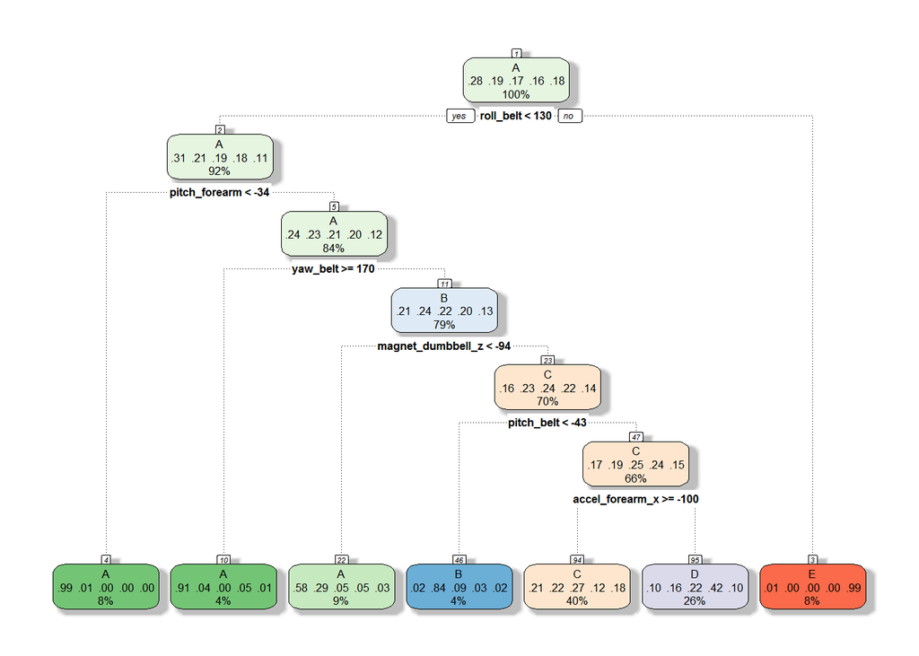

```r
modfit1 <- train(classe ~ .,method='rpart',data=training)
fancyRpartPlot(modfit1$finalModel, sub="")
```

```r
pred=predict(modfit1,newdata=testing)
z=confusionMatrix(pred,testing$classe)
z$table
```

```
##           Reference
## Prediction    A    B    C    D    E
##          A 1357  229   38   66   15
##          B    3  259   28    8   10
##          C  693  725  819  389  557
##          D  171  305  483  823  200
##          E    8    0    0    0  660
```

```r
z$overall[1]
```

```
##  Accuracy
## 0.4993627
```

From the confusion matrix it is clear the accuracy of “0.49” for this model fit clearly shows “no purity” hence this model fit is rejected.

### b) Random Forest Method

Using Random forest method to do the prediction.

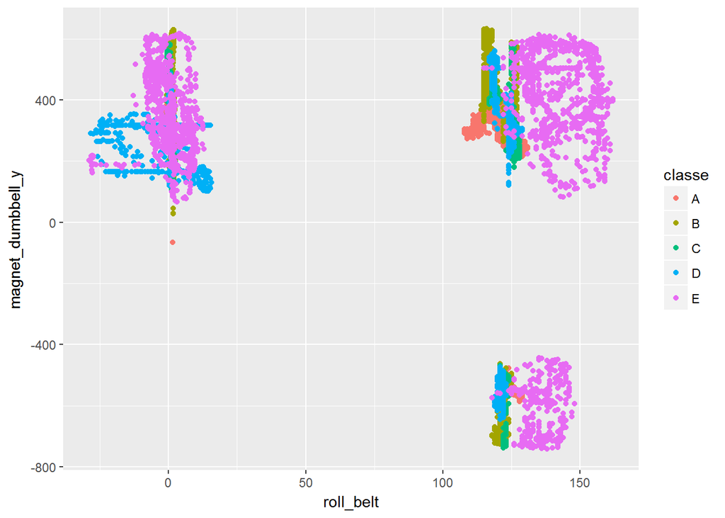

```r
modfit2=randomForest(classe~., data=training, method='class')
pred2 = predict(modfit2,testing,type='class')
qplot(roll_belt, magnet_dumbbell_y, colour=classe, data=training)
```

```r
z2=confusionMatrix(pred2,testing$classe)
z2$table
```

```
##           Reference
## Prediction    A    B    C    D    E
##          A 2231    7    0    0    0
##          B    1 1507    6    0    0
##          C    0    4 1361   16    3
##          D    0    0    1 1268    4
##          E    0    0    0    2 1435
```

```r
z2$overall[1]
```

```
## Accuracy
## 0.994392
```

Random forest prediction model provides 99% accurancy hence this model has been choosen to do predict the testing data set.

## Conclusion

```r
pred3 =  predict(modfit2,testingSet,type='class')
nofiles = length(pred3)
for (i in 1:nofiles){
    filename =  paste0("problem_id",i,".txt")
    write.table(pred3[i],file=filename,quote=FALSE,row.names=FALSE,col.names=FALSE)
}
pred3
```

```
##  1  2  3  4  5  6  7  8  9 10 11 12 13 14 15 16 17 18 19 20
##  B  A  B  A  A  E  D  B  A  A  B  C  B  A  E  E  A  B  B  B
## Levels: A B C D E
```